# DATA202 Midterm Project

Sherise Immanuela & Tanya Nyamwiwa

## Overview

We are interested in the relationship between the S&P 500 stock volume and price because it is generally believed that trading volume is a good indicator of stock price, and vice versa. We chose to replicate a plot from the following article: [Opinion: Time to worry? Trading volume is rising when stocks are falling](https://www.marketwatch.com/story/time-to-worry-trading-volume-is-rising-when-stocks-are-falling-2018-04-27)

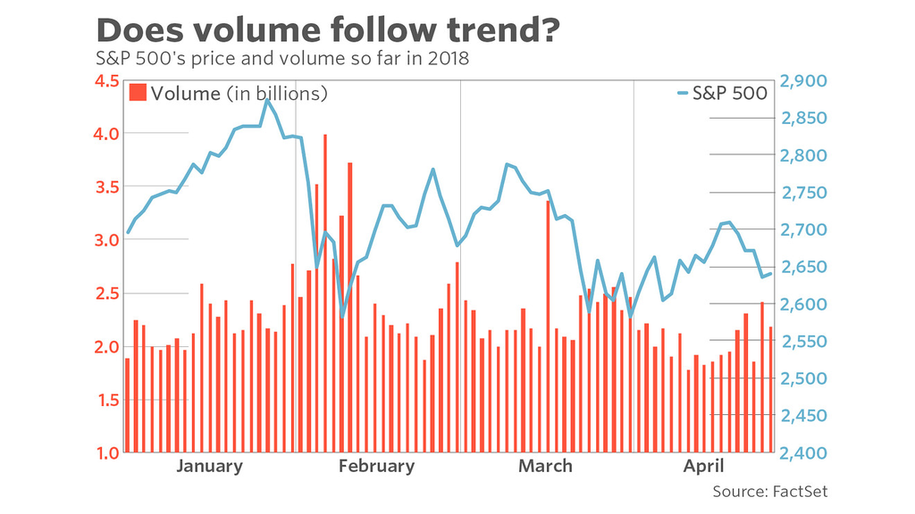

```r
knitr::include_graphics("https://ei.marketwatch.com/Multimedia/2018/04/26/Photos/ZG/MW-GI064_volume_20180426124007_ZG.jpg?uuid=7ac8348a-4970-11e8-8e97-ac162d7bc1f7")
```

Claim:

> The movements of price and volume of the S&P 500 tend to happen at the same time rather than one being consistently before or after the other. In other words, neither price nor volume is a leading or lagging indicator of the other.

## Design

The visualization the author chose was a bar graph and line graph combined. The x-axis represents days in 2018 (January-April). The left y-axis shows the S&P trading volume in billions. The right y-axis shows the S&P 500’s price.

First, they made use of color. The line graph for the S&P 500 price is in blue, while the bar graph for the S&P 500 volume is in red. Second, they used lines to separate the whole plot in 4 (to separate each month). Third, they “freed” the y-axis on both sides to represent two different scales.

For at least one of these variables, describe what makes that choice appropriate or inappropriate. We think the slightly transparent lines are appropriate so we can see more clearly the difference of movements between the months.

First, we think that the use of free y-axis scales are effective, because we can see the proportions of the two graphs accurately. We can see the distribution of the two graphs easily. One thing we think can be done more effectively is adding points on the line graph so we can see the actual change in price more clearly. Because the width of the column bars are very tight, it would be better if we can “zoom in” on the line graph.

## Data

### Data Overview

We couldn’t find the data from the source the article uses. However, because are data is made readily available on other sites, we are able to find the same data they used.

The author of the article sourced the data from FactSet. However, the original data simply comes from S&P/the stock market.

Direct URL:

[Yahoo Finance Historical Data of the S&P 500](https://finance.yahoo.com/quote/%5EGSPC/history?p=%5EGSPC)

The S&P 500 is publicly published data, so we can use it however we want.

We can directly source the data from the S&P 500 website. However, many trusted sources like Yahoo Finance provide the same exact data.

As mentioned above, the data just comes from the S&P 500. The article is written by Mark Hulbert and published on MarketWatch.

As far as we know, no processing have been done to it.

From Investopedia, we know that the S&P 500 price is calculated by taking “the number of outstanding shares of each company and multiplies that number by the company’s current share price, or market value.”

### Data Details

```r
sp_fiveyears <- read_csv("data/all_stocks_5yr.csv")
glimpse(sp_fiveyears)
```

```
## Rows: 619,040
## Columns: 7
## $ date   <date> 2013-02-08, 2013-02-11, 2013-02-12, 2013-02-13, 2013-02-14, 20…
## $ open   <dbl> 15.07, 14.89, 14.45, 14.30, 14.94, 13.93, 14.33, 14.17, 13.62, …
## $ high   <dbl> 15.12, 15.01, 14.51, 14.94, 14.96, 14.61, 14.56, 14.26, 13.95, …
## $ low    <dbl> 14.63, 14.26, 14.10, 14.25, 13.16, 13.93, 14.08, 13.15, 12.90, …
## $ close  <dbl> 14.75, 14.46, 14.27, 14.66, 13.99, 14.50, 14.26, 13.33, 13.37, …
## $ volume <dbl> 8407500, 8882000, 8126000, 10259500, 31879900, 15628000, 113544…
## $ Name   <chr> "AAL", "AAL", "AAL", "AAL", "AAL", "AAL", "AAL", "AAL", "AAL", …
```

For five years of S&P 500 data (price and volume), the data has 7 columns with the variables `date`, `open`, `high`, `low`, `close`, `volume`, and `Name`.

A single row represents the open, close, highest, and lowest price, and volume of one stock in the S&P 500 in a single day.

There are 619040 rows.

### Wrangling

- We filtered the dataset to include only data from January to mid-April.
- We tried fixing the format of the date (previously qualitative e.g., 22-Jan-2018) in R, but we didn’t succeed. So we formatted it in Excel to a quantitative format (e.g., 2018-01-22) and reuploaded it as a CSV in R.

```r
sp2018 <- read_csv("data/2018spdata.csv")
```